# STAT_Final

```python
clusteringModel = KMeans(n_clusters=2)
clusteringModel.fit(X)
preds = clusteringModel.predict(X)
```

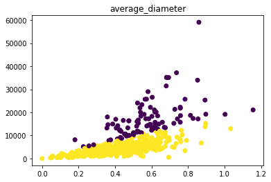

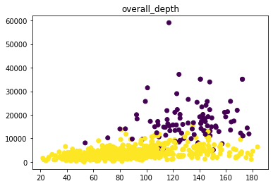

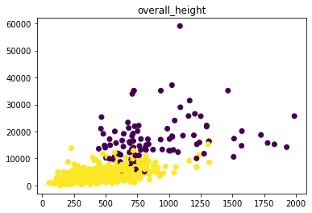

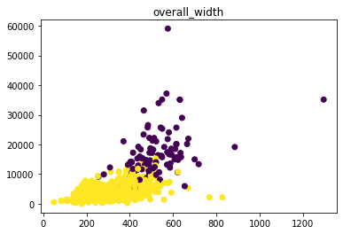

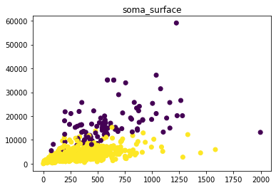

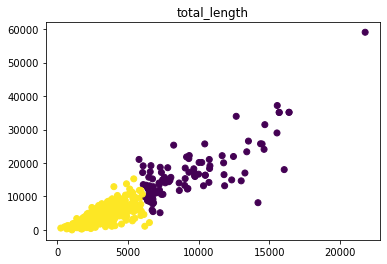

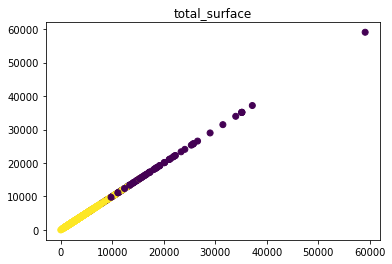

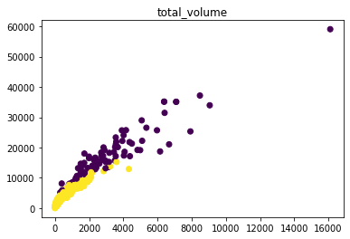

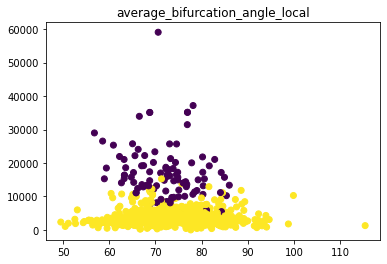

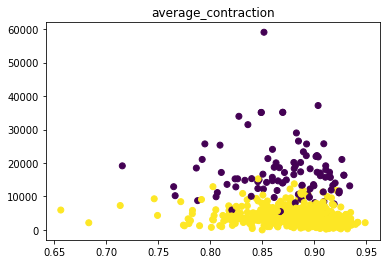

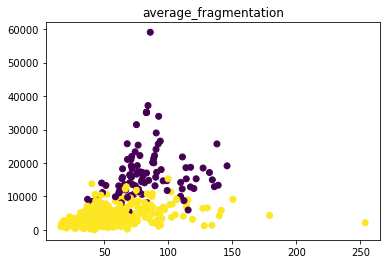

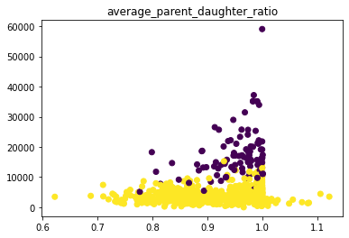

[8 more figures not shown]

```python
for i in ful_data[1:]:
    plt.title(i)
    plt.scatter(ful_data[i], y, c=preds)
    plt.show()
```

##### as per my observation Number Branches Overall height and soma surface are the most discrimatory features the reason being they have most scatterd graph and outliers in them

```python
import matplotlib.pyplot as plt
import numpy as np
from sklearn.datasets import make_blobs
from sklearn.cluster import MeanShift, estimate_bandwidth
```

```python
# Configuration options
num_samples_total = 10000
cluster_centers = X
num_classes = len(cluster_centers)
```

##### With make_blobs, we can let Scikit-learn make the blobs we want. We set the configuration that we just defined, and set a cluster standard deviation of 0.30. This can be pretty much anything, and I'd recommend that you play around a bit before you start the actual clustering

```python
# Generate data
X, targets = make_blobs(n_samples = num_samples_total, centers = cluster_centers, n_features = num_classes, center_box=(0, 1), cluster_std = 0.30)
```

```python
bandwidth = estimate_bandwidth(X, quantile=0.2, n_samples=500)
```

```python
meanshift = MeanShift(bandwidth=bandwidth)
meanshift.fit(X)
labels = meanshift.labels_
labels_unique = np.unique(labels)
n_clusters_ = len(labels_unique)
```

```python
# Predict the cluster for all the samples
P = meanshift.predict(X)
```

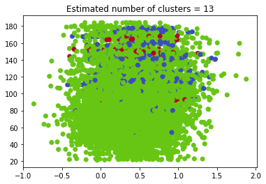

```python
# Generate scatter plot for training data
colors = list(map(lambda x: '#3b4cc0' if x == 1 else '#b40426' if x == 2 else '#67c614', P))
plt.scatter(X[:,0], X[:,1], c=colors, marker="o", picker=True)
plt.title(f'Estimated number of clusters = {n_clusters_}')
plt.show()
```

##### Suppose that you have a dataset in which you want to discover groups, or clusters, that share certain characteristics. There are various unsupervised machine learning techniques that can be used to do this. As we've seen in other blogs, K-means clustering can be used if you have good data or small data

##### But in both cases, the clusters need to be separated. Or you may need to configure the number of clusters in advance.

##### Mean Shift clustering, a clustering approach for discovering "blobs in a smooth density of samples". That is, precisely what you want - discovering clusters if your data is not separated without configuring the number of clusters.

##### This is what the Mean Shift algorithm for clustering does. It looks at the "mode" of the density, and where it is highest, and will iteratively shift points in the plot towards the closest mode

##### with this we can find out the clusters where there is highest density

##### unlike k means this works good on small data